# latihanpraktikum

Adisti Suci Rahmah

2023-09-21

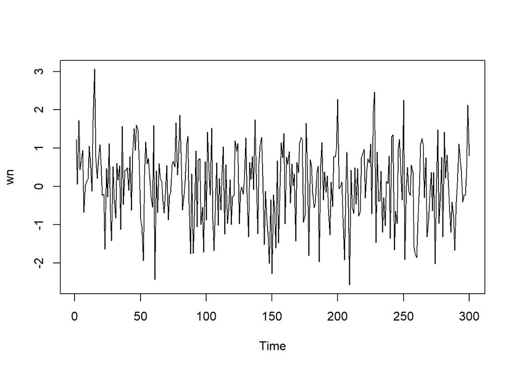

```r
wn <- rnorm(300)
ts.plot(wn)
```

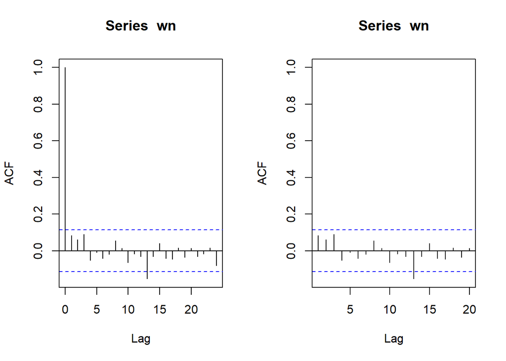

```r
par(mfrow = c(1, 2))
acf(wn)
acf(wn, xlim = c(1, 20))
```

## Karakteristik MA(1)

Proses MA dapat dituliskan sebagai berikut:

$$y_{t} = c + e_t + \theta_{1}e_{t-1} + \theta_{2}e_{t-2} + \dots +
\theta_{q}e_{t-q} = c+{e_t+\sum_{i=1}^p \theta_ie_{t-i}}$$
Terlihat bahwa $e_t$, atau *white noise*, berperan penting dalam pembangkitan proses MA.

```r
set.seed(1027)
ma <- wn[1]
ma
```

```
## [1] 1.218957
```

$$y_t = e_t+0.4e_{t-1}+0.6e_{t-2}$$

```r
for(i in 3:300){
   ma[i] <- wn[i] + 0.4 * wn[i - 1] + 0.6 * wn[i - 2]
}
ma
```

```
##   [1]  1.218957443           NA  2.483742919  1.165801205  1.928455766
##   [6]  1.485688079  0.127658400  0.319206714 -0.267212302  0.262512486
##  [11]  1.205600771  1.026307463  0.698497431  1.986966072  3.685685620
##  [16]  3.029904894  2.346557062  1.229061263  1.488133127  1.399804463
##  [21]  0.643423699  0.034487902 -1.861919613 -0.314257455 -1.075456690
##  [26]  1.290712746 -0.347371149 -0.994614995 -0.427033720 -0.975170532
##  [31] -0.652755219  0.081383440 -0.081828084  0.973601470 -0.807929339
##  [36]  1.446011427 -0.521533589  1.170664975  0.314895084  0.908769733
##  [41]  0.352907188  1.032232781 -0.368845595  1.078764656  1.481264471
##  [46]  2.057968776  2.886470430  2.676005640  2.238228857  0.297205307
##  [51] -0.970775418 -2.867113997 -1.107919149  0.118934790  1.232306825
##  [56]  1.668277333  0.826156184  0.243511219 -0.546970967  1.219167242
##  [61] -2.115871404  0.393244200 -1.976808666  0.568644862  0.051224927
##  [66]  0.568481294 -0.192476604 -0.768155326 -0.573386367  0.109267563
##  [71] -0.702693843 -0.277945694 -0.787245353  0.348525857  0.793744143
```

[output cut: 45 more lines]

Selain menggunakan cara di atas, pembangkitan proses MA(2) dapat dilakukan dengan fungsi `arima.sim()` sebagai berikut.

```r
ma2 <- arima.sim(list(order=c(0,0,2), ma= c(0.4, 0.6)), n = 300)
ma2
```

```
## Time Series:
## Start = 1
## End = 300
## Frequency = 1
##   [1] -0.299980544 -1.852572963 -1.715450757 -1.397720392 -1.784340465
##   [6] -0.905112941 -0.100103348  1.445671239  1.515663345  3.039405756
##  [11]  1.291841111 -1.200037089 -0.470284084 -1.441768264 -0.869340798
##  [16]  0.389147954 -2.184264194  0.894137224 -0.975137961 -0.496492188
##  [21] -0.313751845 -1.004580345  0.860669374 -0.763632585 -2.917777487
##  [26] -1.330041152 -0.895484158  1.107052744  1.171047509  0.706487030
##  [31]  0.289881631  1.732467457 -0.347095355  1.552100998 -0.011654270
##  [36] -0.554373740 -1.329068660 -1.772462164 -1.299294702 -0.067662818
##  [41]  0.552417473 -0.831668932 -0.440545274  0.310034829  0.082173723
##  [46]  1.448421338  0.584588144  1.506414883  1.667151541 -0.297639236
##  [51] -0.621532569 -1.834386515 -2.149911881 -1.059828601 -1.163455100
```

[output cut: 49 more lines]

### Plot Time Series

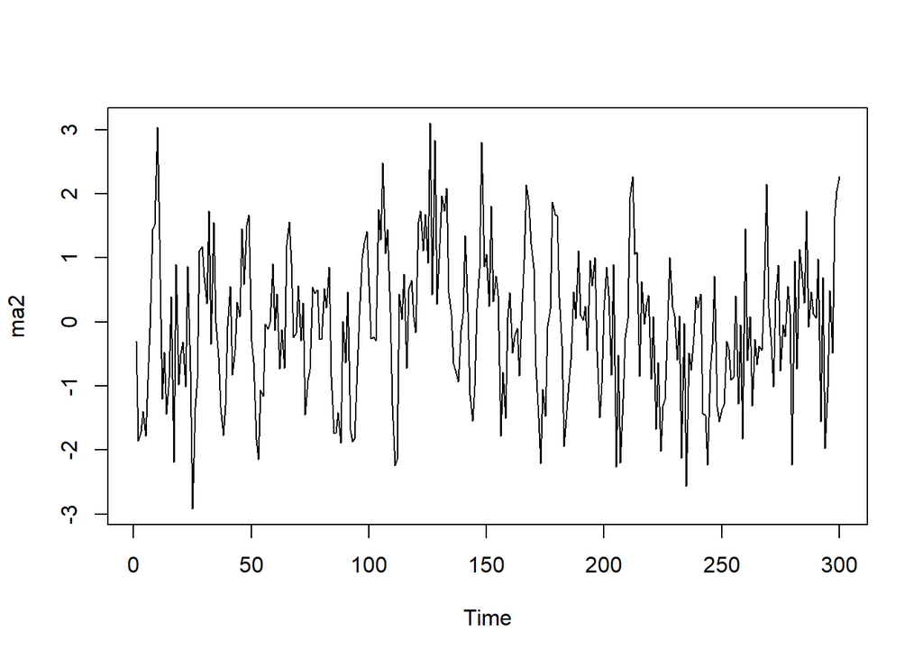

```r
ts.plot(ma2)
```

Berdasarkan plot time series, terlihat bahwa data MA(2) yang dibangkitkan stasioner dalam rataan

### Plot ACF

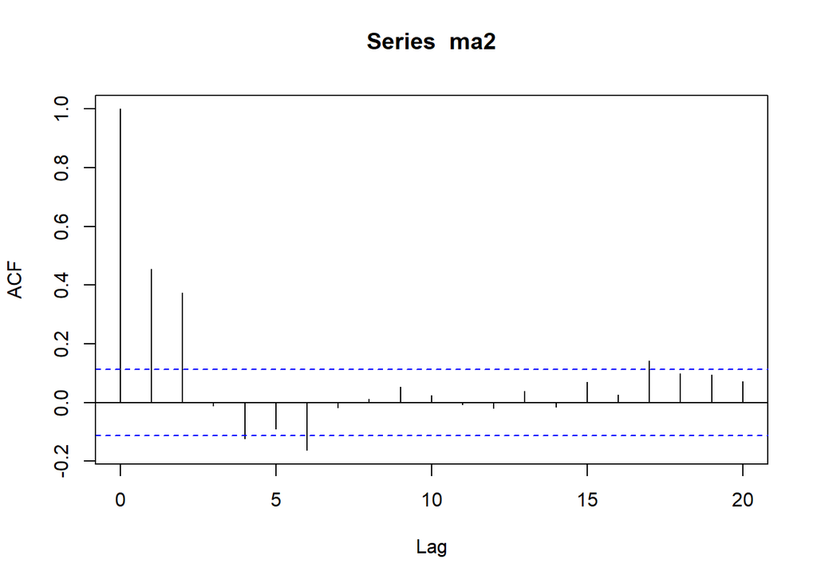

```r
acf(ma2,lag.max = 20)
```

### Plot PACF

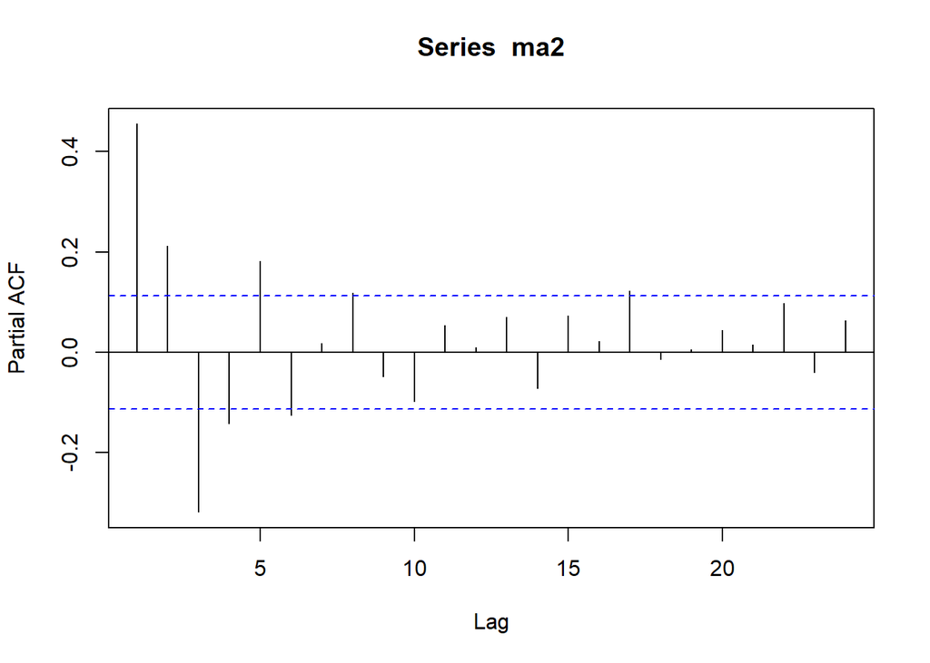

```r
pacf(ma2)
```

Berdasarkan plot PACF tersebut, terlihat bahwa plot PACF cenderung *tails off* dan membentuk gelombang sinus

### Plot EACF

```r
TSA::eacf(ma2)
```

```
## AR/MA
##   0 1 2 3 4 5 6 7 8 9 10 11 12 13
## 0 x x o x o x o o o o o  o  o  o
## 1 x x o x o x o o o o o  o  o  o
## 2 x x x x o x o o o o o  o  o  o
## 3 x x x x x x o o o o o  o  o  o
## 4 x x x x x x o o o o o  o  o  o
## 5 x x o x x x o o o o o  o  o  o
## 6 o x o x o x o o o o o  o  o  o
## 7 o x x o o o o o o o o  o  o  o
```

### Scatterplot Antar Lag

#### Korelasi antara $Y_t$ dengan $Y_{t-1}$, $Y_t$ dengan $Y_{t-2}$, dan $Y_t$ dengan $Y_{t-3}$

```r
#Yt
yt_ma <- ma[-1]
yt_ma
```

```
##   [1]           NA  2.483742919  1.165801205  1.928455766  1.485688079
##   [6]  0.127658400  0.319206714 -0.267212302  0.262512486  1.205600771
##  [11]  1.026307463  0.698497431  1.986966072  3.685685620  3.029904894
##  [16]  2.346557062  1.229061263  1.488133127  1.399804463  0.643423699
##  [21]  0.034487902 -1.861919613 -0.314257455 -1.075456690  1.290712746
##  [26] -0.347371149 -0.994614995 -0.427033720 -0.975170532 -0.652755219
##  [31]  0.081383440 -0.081828084  0.973601470 -0.807929339  1.446011427
##  [36] -0.521533589  1.170664975  0.314895084  0.908769733  0.352907188
##  [41]  1.032232781 -0.368845595  1.078764656  1.481264471  2.057968776
##  [46]  2.886470430  2.676005640  2.238228857  0.297205307 -0.970775418
##  [51] -2.867113997 -1.107919149  0.118934790  1.232306825  1.668277333
##  [56]  0.826156184  0.243511219 -0.546970967  1.219167242 -2.115871404
##  [61]  0.393244200 -1.976808666  0.568644862  0.051224927  0.568481294
##  [66] -0.192476604 -0.768155326 -0.573386367  0.109267563 -0.702693843
##  [71] -0.277945694 -0.787245353  0.348525857  0.793744143  1.115578305
```

[output cut: 45 more lines]

```r
#Yt-1
yt_1_ma <- ma[-300]
yt_1_ma
```

```
##   [1]  1.218957443           NA  2.483742919  1.165801205  1.928455766
##   [6]  1.485688079  0.127658400  0.319206714 -0.267212302  0.262512486
##  [11]  1.205600771  1.026307463  0.698497431  1.986966072  3.685685620
##  [16]  3.029904894  2.346557062  1.229061263  1.488133127  1.399804463
##  [21]  0.643423699  0.034487902 -1.861919613 -0.314257455 -1.075456690
##  [26]  1.290712746 -0.347371149 -0.994614995 -0.427033720 -0.975170532
##  [31] -0.652755219  0.081383440 -0.081828084  0.973601470 -0.807929339
##  [36]  1.446011427 -0.521533589  1.170664975  0.314895084  0.908769733
##  [41]  0.352907188  1.032232781 -0.368845595  1.078764656  1.481264471
##  [46]  2.057968776  2.886470430  2.676005640  2.238228857  0.297205307
##  [51] -0.970775418 -2.867113997 -1.107919149  0.118934790  1.232306825
##  [56]  1.668277333  0.826156184  0.243511219 -0.546970967  1.219167242
##  [61] -2.115871404  0.393244200 -1.976808666  0.568644862  0.051224927
##  [66]  0.568481294 -0.192476604 -0.768155326 -0.573386367  0.109267563
##  [71] -0.702693843 -0.277945694 -0.787245353  0.348525857  0.793744143
```

[output cut: 45 more lines]

```r
#Yt
yt_ma2 <- ma[-c(1,3)]
yt_ma2
```

```
##   [1]           NA  1.165801205  1.928455766  1.485688079  0.127658400
##   [6]  0.319206714 -0.267212302  0.262512486  1.205600771  1.026307463
##  [11]  0.698497431  1.986966072  3.685685620  3.029904894  2.346557062
##  [16]  1.229061263  1.488133127  1.399804463  0.643423699  0.034487902
##  [21] -1.861919613 -0.314257455 -1.075456690  1.290712746 -0.347371149
##  [26] -0.994614995 -0.427033720 -0.975170532 -0.652755219  0.081383440
##  [31] -0.081828084  0.973601470 -0.807929339  1.446011427 -0.521533589
##  [36]  1.170664975  0.314895084  0.908769733  0.352907188  1.032232781
##  [41] -0.368845595  1.078764656  1.481264471  2.057968776  2.886470430
##  [46]  2.676005640  2.238228857  0.297205307 -0.970775418 -2.867113997
##  [51] -1.107919149  0.118934790  1.232306825  1.668277333  0.826156184
##  [56]  0.243511219 -0.546970967  1.219167242 -2.115871404  0.393244200
##  [61] -1.976808666  0.568644862  0.051224927  0.568481294 -0.192476604
##  [66] -0.768155326 -0.573386367  0.109267563 -0.702693843 -0.277945694
##  [71] -0.787245353  0.348525857  0.793744143  1.115578305  2.266997616
```

[output cut: 45 more lines]

```r
#Yt-2
yt_2_ma <- ma[-c(299, 300)]
yt_2_ma
```

```
##   [1]  1.218957443           NA  2.483742919  1.165801205  1.928455766
##   [6]  1.485688079  0.127658400  0.319206714 -0.267212302  0.262512486
##  [11]  1.205600771  1.026307463  0.698497431  1.986966072  3.685685620
##  [16]  3.029904894  2.346557062  1.229061263  1.488133127  1.399804463
##  [21]  0.643423699  0.034487902 -1.861919613 -0.314257455 -1.075456690
##  [26]  1.290712746 -0.347371149 -0.994614995 -0.427033720 -0.975170532
##  [31] -0.652755219  0.081383440 -0.081828084  0.973601470 -0.807929339
##  [36]  1.446011427 -0.521533589  1.170664975  0.314895084  0.908769733
##  [41]  0.352907188  1.032232781 -0.368845595  1.078764656  1.481264471
##  [46]  2.057968776  2.886470430  2.676005640  2.238228857  0.297205307
##  [51] -0.970775418 -2.867113997 -1.107919149  0.118934790  1.232306825
##  [56]  1.668277333  0.826156184  0.243511219 -0.546970967  1.219167242
##  [61] -2.115871404  0.393244200 -1.976808666  0.568644862  0.051224927
##  [66]  0.568481294 -0.192476604 -0.768155326 -0.573386367  0.109267563
##  [71] -0.702693843 -0.277945694 -0.787245353  0.348525857  0.793744143
```

[output cut: 45 more lines]

```r
#Yt
yt_ma3 <- ma[-c(1,2,3)]
yt_ma3
```

```
##   [1]  1.165801205  1.928455766  1.485688079  0.127658400  0.319206714
##   [6] -0.267212302  0.262512486  1.205600771  1.026307463  0.698497431
##  [11]  1.986966072  3.685685620  3.029904894  2.346557062  1.229061263
##  [16]  1.488133127  1.399804463  0.643423699  0.034487902 -1.861919613
##  [21] -0.314257455 -1.075456690  1.290712746 -0.347371149 -0.994614995
##  [26] -0.427033720 -0.975170532 -0.652755219  0.081383440 -0.081828084
##  [31]  0.973601470 -0.807929339  1.446011427 -0.521533589  1.170664975
##  [36]  0.314895084  0.908769733  0.352907188  1.032232781 -0.368845595
##  [41]  1.078764656  1.481264471  2.057968776  2.886470430  2.676005640
##  [46]  2.238228857  0.297205307 -0.970775418 -2.867113997 -1.107919149
##  [51]  0.118934790  1.232306825  1.668277333  0.826156184  0.243511219
##  [56] -0.546970967  1.219167242 -2.115871404  0.393244200 -1.976808666
##  [61]  0.568644862  0.051224927  0.568481294 -0.192476604 -0.768155326
##  [66] -0.573386367  0.109267563 -0.702693843 -0.277945694 -0.787245353
##  [71]  0.348525857  0.793744143  1.115578305  2.266997616  1.270983867
```

[output cut: 45 more lines]

```r
#Yt-3
yt_3_ma <- ma[-c(298, 299, 300)]
yt_3_ma
```

```
##   [1]  1.218957443           NA  2.483742919  1.165801205  1.928455766
##   [6]  1.485688079  0.127658400  0.319206714 -0.267212302  0.262512486
##  [11]  1.205600771  1.026307463  0.698497431  1.986966072  3.685685620
##  [16]  3.029904894  2.346557062  1.229061263  1.488133127  1.399804463
##  [21]  0.643423699  0.034487902 -1.861919613 -0.314257455 -1.075456690
##  [26]  1.290712746 -0.347371149 -0.994614995 -0.427033720 -0.975170532
##  [31] -0.652755219  0.081383440 -0.081828084  0.973601470 -0.807929339
##  [36]  1.446011427 -0.521533589  1.170664975  0.314895084  0.908769733
##  [41]  0.352907188  1.032232781 -0.368845595  1.078764656  1.481264471
##  [46]  2.057968776  2.886470430  2.676005640  2.238228857  0.297205307
##  [51] -0.970775418 -2.867113997 -1.107919149  0.118934790  1.232306825
##  [56]  1.668277333  0.826156184  0.243511219 -0.546970967  1.219167242
##  [61] -2.115871404  0.393244200 -1.976808666  0.568644862  0.051224927
##  [66]  0.568481294 -0.192476604 -0.768155326 -0.573386367  0.109267563
##  [71] -0.702693843 -0.277945694 -0.787245353  0.348525857  0.793744143
```

[output cut: 45 more lines]

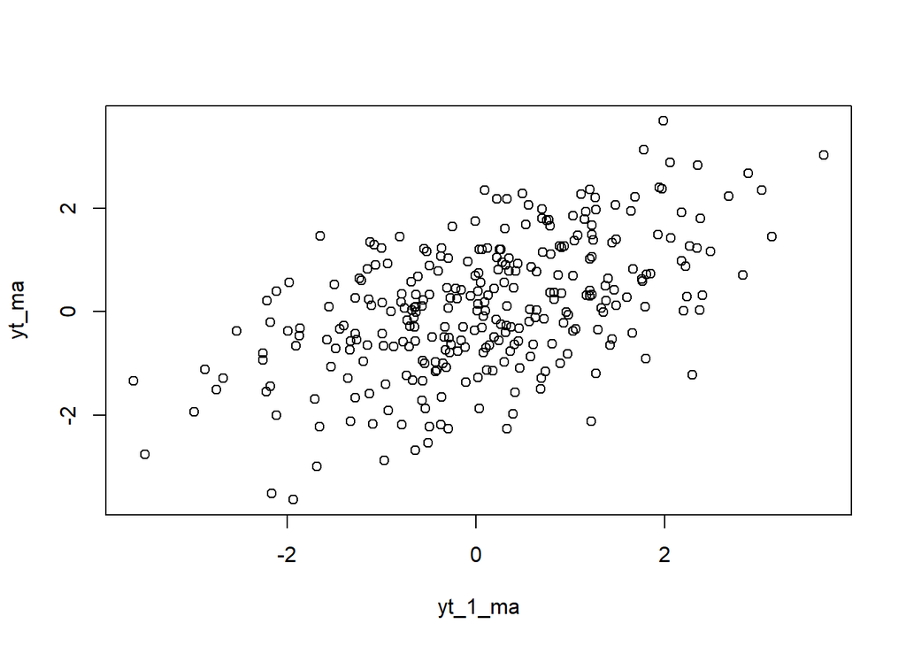

```r
plot(y = yt_ma, x = yt_1_ma)
```

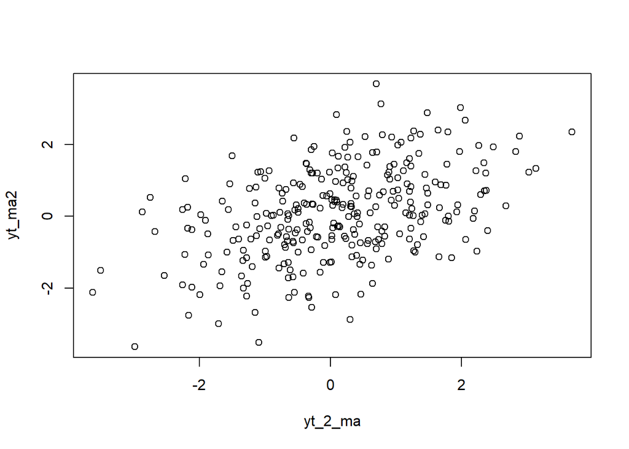

```r
plot(y = yt_ma2, x = yt_2_ma)
```

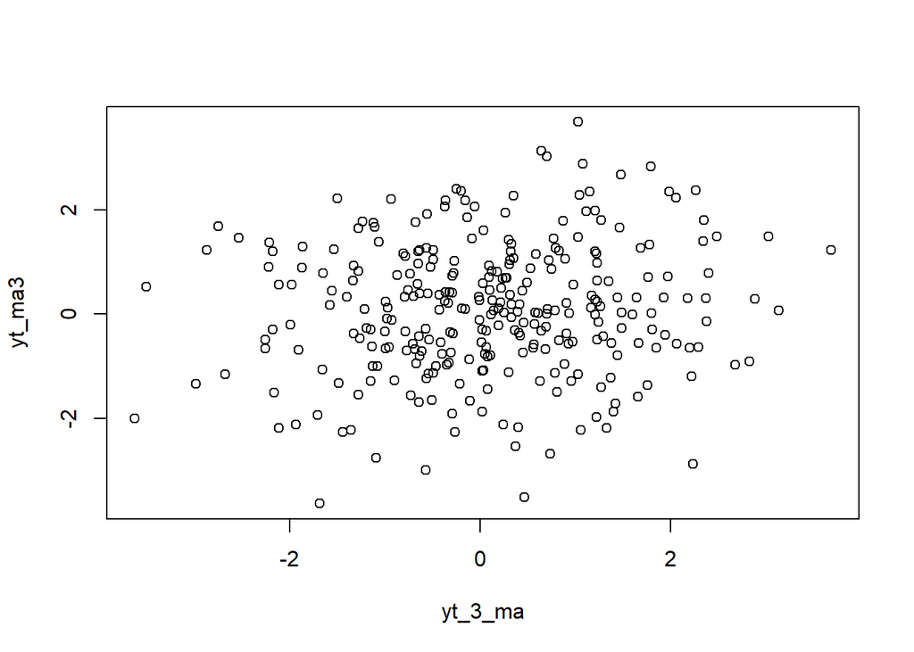

```r
plot(y = yt_ma3, x = yt_3_ma)
```

Berdasarkan scatterplot tersebut, terlihat bahwa terdapat hubungan positif antara $Y_t$ dengan $Y_{t-1}$ dan $Y_t$ dengan $Y_{t-2}$. Namun terlihat bahwa cenderung tidak terdapat hubungan antara $Y_t$ dengan $Y_{t-3}$

```r
cor(yt_ma,yt_1_ma)
```

```
## [1] NA
```

```r
cor(yt_ma2,yt_2_ma)
```

```
## [1] NA
```

```r
cor(yt_ma3,yt_3_ma)
```

```
## [1] NA
```

## Proses AR

Proses AR dapat dituliskan sebagai berikut:

$$y_{t} = c + e_t + \phi_{1}Y_{t-1} +
\phi_{2}Y_{t-2} + \dots + \phi_{q}Y_{t-q} = c+{e_t+\sum_{i=1}^p
\phi_iY_{t-i}}$$
Terlihat bahwa $Y_t$ berperan penting dalam pembangkitan proses AR.

## Pembangkitan Proses AR

```r
set.seed(1027)
```

$$Y_t = e_t+0.5Y_{t-1}+0.2Y_{t-2}$$

```r
n<-length(wn)
n
```

```
## [1] 300
```

```r
ar <- c(1:n)
for (i in 3:n) {ar[i]<-wn[i]+0.5*ar[i-1]+0.2*ar[i-2]}
ar
```

```
##   [1]  1.000000000  2.000000000  2.928258304  2.302461812  2.453050287
##   [6]  2.623238901  1.125698718  1.115583332  0.910403105  0.872990311
##  [11]  1.669824693  1.498515050  0.955368688  2.522092152  4.516635780
##  [16]  3.520011949  2.868270361  2.830858563  3.077165745  2.653693496
##  [21]  1.713278597  1.184103073 -0.708501607  0.347560856 -0.243447683
##  [26]  1.069717564 -0.144656924 -1.273827017 -0.148206084 -0.661829260
##  [31] -1.190710026 -0.114499265 -0.124415855  0.452170416 -0.924224050
##  [36]  1.202137002 -0.059580223  0.627334863  0.735449790  0.978463695
##  [41]  0.534901221  1.244781267  0.108722466  1.161358756  2.112860882
##  [46]  2.227671402  3.141028417  3.486824387  3.058764051  1.366628202
##  [51]  0.256051269 -1.534085245 -0.426167524  0.644429953  0.829757084
##  [56]  1.276333162  0.981581363  0.479042010 -0.110805587  1.638439179
##  [61] -1.630040641 -0.082068782 -1.049697199  0.057286156  0.040101968
##  [66]  0.152301070 -0.289461815 -0.805448635 -0.533352225  0.125302706
##  [71] -0.924299027 -0.694763819 -0.688249168  0.082456398  0.564713482
```

[output cut: 45 more lines]

Selain menggunakan cara di atas, pembangkitan proses AR dapat dilakukan dengan fungsi `arima.sim()` sebagai berikut.

```r
ar2 <- arima.sim(list(order=c(2,0,0), ar= c(0.5, 0.2)), n = 300)
ar2
```

```
## Time Series:
## Start = 1
## End = 300
## Frequency = 1
##   [1] -0.886123785 -3.504255227 -1.515173657 -0.648718408 -0.092736206
##   [6]  0.295240953  0.326224533  0.150369927  1.783322761 -0.039442828
##  [11]  1.287779679  0.820719303 -0.530847289 -1.061674111 -1.306053221
##  [16] -1.320800855 -0.405670096  0.152309517 -1.393934672 -0.923051384
##  [21]  0.505713830 -0.194062650  0.809840620  0.785789825  1.409967594
##  [26]  1.935442252  0.009692479 -0.377569307 -0.969417774 -1.935403585
##  [31] -1.201798644 -1.310241318 -0.775799735 -0.611695826 -0.555021210
##  [36]  0.526071985 -0.296195742  0.018530879 -0.540033827 -0.224465732
##  [41] -0.662140224  0.970150712  1.644329029  0.605502484 -0.215824968
##  [46]  0.426827018  1.079151371 -0.283129047  0.188879025 -0.908947374
##  [51] -1.018385417 -0.622849502  0.365474795  0.110795916  0.084888478
```

[output cut: 49 more lines]

## Karakteristik AR(2)

### Plot Time Series

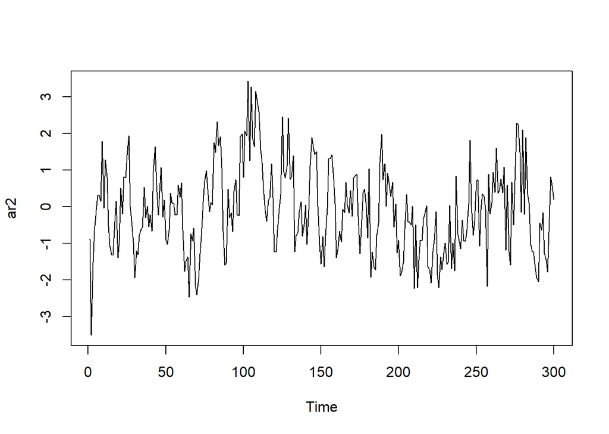

```r
ts.plot(ar2)
```

Berdasarkan plot time series tersebut terlihat bahwa data cenderung stasioner pada rataan

### Plot ACF

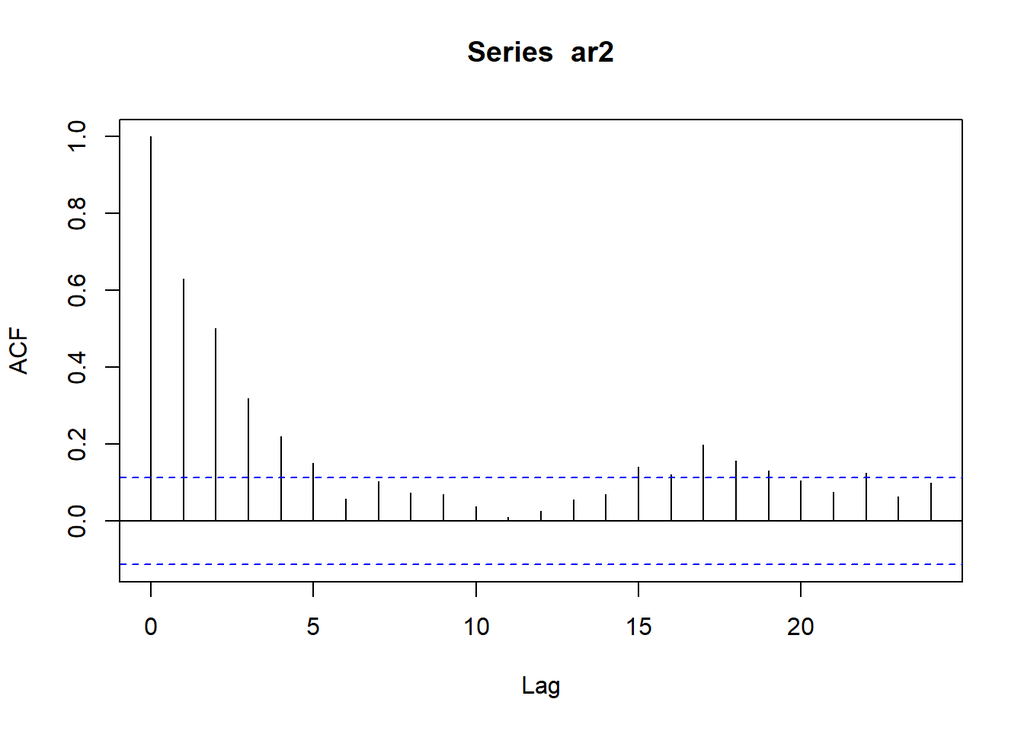

```r
acf(ar2)
```

Berdasarkan plot ACF tersebut terlihat bahwa plot ACF cenderung *tails off*

### Plot PACF

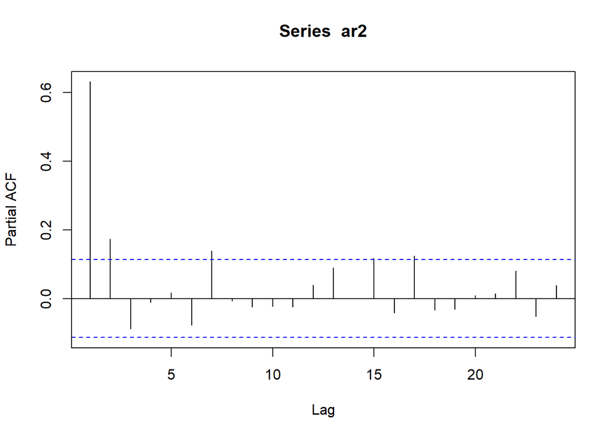

```r
pacf(ar2)
```

### Plot EACF

```r
TSA::eacf(ar2)
```

```
## AR/MA
##   0 1 2 3 4 5 6 7 8 9 10 11 12 13
## 0 x x x x x o o o o o o  o  o  o
## 1 x x o o o o o o o o o  o  o  o
## 2 x x o o o x o o o o o  o  o  o
## 3 x x o o o x x o o o o  o  o  o
## 4 x o o o o x x o o o o  o  o  o
## 5 x x o x o o o o o o o  o  o  o
## 6 x x x x x o o o o o o  o  o  o
## 7 o x x x o x o o o o o  o  o  o
```

### Scatterplot Antar Lag

#### Korelasi antara $Y_t$ dengan $Y_{t-1}$,$Y_t$ dengan $Y_{t-2}$, dan $Y_t$ dengan $Y_{t-3}$

```r
#Yt
yt_ar <- ar[-1]
yt_ar
```

```
##   [1]  2.000000000  2.928258304  2.302461812  2.453050287  2.623238901
##   [6]  1.125698718  1.115583332  0.910403105  0.872990311  1.669824693
##  [11]  1.498515050  0.955368688  2.522092152  4.516635780  3.520011949
##  [16]  2.868270361  2.830858563  3.077165745  2.653693496  1.713278597
##  [21]  1.184103073 -0.708501607  0.347560856 -0.243447683  1.069717564
##  [26] -0.144656924 -1.273827017 -0.148206084 -0.661829260 -1.190710026
##  [31] -0.114499265 -0.124415855  0.452170416 -0.924224050  1.202137002
##  [36] -0.059580223  0.627334863  0.735449790  0.978463695  0.534901221
##  [41]  1.244781267  0.108722466  1.161358756  2.112860882  2.227671402
##  [46]  3.141028417  3.486824387  3.058764051  1.366628202  0.256051269
##  [51] -1.534085245 -0.426167524  0.644429953  0.829757084  1.276333162
##  [56]  0.981581363  0.479042010 -0.110805587  1.638439179 -1.630040641
##  [61] -0.082068782 -1.049697199  0.057286156  0.040101968  0.152301070
##  [66] -0.289461815 -0.805448635 -0.533352225  0.125302706 -0.924299027
##  [71] -0.694763819 -0.688249168  0.082456398  0.564713482  0.810652031
```

[output cut: 45 more lines]

```r
#Yt-1
yt_1_ar <- ar[-300]
yt_1_ar
```

```
##   [1]  1.000000000  2.000000000  2.928258304  2.302461812  2.453050287
##   [6]  2.623238901  1.125698718  1.115583332  0.910403105  0.872990311
##  [11]  1.669824693  1.498515050  0.955368688  2.522092152  4.516635780
##  [16]  3.520011949  2.868270361  2.830858563  3.077165745  2.653693496
##  [21]  1.713278597  1.184103073 -0.708501607  0.347560856 -0.243447683
##  [26]  1.069717564 -0.144656924 -1.273827017 -0.148206084 -0.661829260
##  [31] -1.190710026 -0.114499265 -0.124415855  0.452170416 -0.924224050
##  [36]  1.202137002 -0.059580223  0.627334863  0.735449790  0.978463695
##  [41]  0.534901221  1.244781267  0.108722466  1.161358756  2.112860882
##  [46]  2.227671402  3.141028417  3.486824387  3.058764051  1.366628202
##  [51]  0.256051269 -1.534085245 -0.426167524  0.644429953  0.829757084
##  [56]  1.276333162  0.981581363  0.479042010 -0.110805587  1.638439179
##  [61] -1.630040641 -0.082068782 -1.049697199  0.057286156  0.040101968
##  [66]  0.152301070 -0.289461815 -0.805448635 -0.533352225  0.125302706
##  [71] -0.924299027 -0.694763819 -0.688249168  0.082456398  0.564713482
```

[output cut: 45 more lines]

```r
#Yt
yt_ar2 <- ar[-c(1,3)]
yt_ar2
```

```
##   [1]  2.000000000  2.302461812  2.453050287  2.623238901  1.125698718
##   [6]  1.115583332  0.910403105  0.872990311  1.669824693  1.498515050
##  [11]  0.955368688  2.522092152  4.516635780  3.520011949  2.868270361
##  [16]  2.830858563  3.077165745  2.653693496  1.713278597  1.184103073
##  [21] -0.708501607  0.347560856 -0.243447683  1.069717564 -0.144656924
##  [26] -1.273827017 -0.148206084 -0.661829260 -1.190710026 -0.114499265
##  [31] -0.124415855  0.452170416 -0.924224050  1.202137002 -0.059580223
##  [36]  0.627334863  0.735449790  0.978463695  0.534901221  1.244781267
##  [41]  0.108722466  1.161358756  2.112860882  2.227671402  3.141028417
##  [46]  3.486824387  3.058764051  1.366628202  0.256051269 -1.534085245
##  [51] -0.426167524  0.644429953  0.829757084  1.276333162  0.981581363
##  [56]  0.479042010 -0.110805587  1.638439179 -1.630040641 -0.082068782
##  [61] -1.049697199  0.057286156  0.040101968  0.152301070 -0.289461815
##  [66] -0.805448635 -0.533352225  0.125302706 -0.924299027 -0.694763819
##  [71] -0.688249168  0.082456398  0.564713482  0.810652031  2.183863654
```

[output cut: 45 more lines]

```r
#Yt-2
yt_2_ar <- ar[-c(299, 300)]
yt_2_ar
```

```
##   [1]  1.000000000  2.000000000  2.928258304  2.302461812  2.453050287
##   [6]  2.623238901  1.125698718  1.115583332  0.910403105  0.872990311
##  [11]  1.669824693  1.498515050  0.955368688  2.522092152  4.516635780
##  [16]  3.520011949  2.868270361  2.830858563  3.077165745  2.653693496
##  [21]  1.713278597  1.184103073 -0.708501607  0.347560856 -0.243447683
##  [26]  1.069717564 -0.144656924 -1.273827017 -0.148206084 -0.661829260
##  [31] -1.190710026 -0.114499265 -0.124415855  0.452170416 -0.924224050
##  [36]  1.202137002 -0.059580223  0.627334863  0.735449790  0.978463695
##  [41]  0.534901221  1.244781267  0.108722466  1.161358756  2.112860882
##  [46]  2.227671402  3.141028417  3.486824387  3.058764051  1.366628202
##  [51]  0.256051269 -1.534085245 -0.426167524  0.644429953  0.829757084
##  [56]  1.276333162  0.981581363  0.479042010 -0.110805587  1.638439179
##  [61] -1.630040641 -0.082068782 -1.049697199  0.057286156  0.040101968
##  [66]  0.152301070 -0.289461815 -0.805448635 -0.533352225  0.125302706
##  [71] -0.924299027 -0.694763819 -0.688249168  0.082456398  0.564713482
```

[output cut: 45 more lines]

```r
#Yt
yt_ar3 <- ar[-c(1,2,3)]
yt_ar3
```

```
##   [1]  2.302461812  2.453050287  2.623238901  1.125698718  1.115583332
##   [6]  0.910403105  0.872990311  1.669824693  1.498515050  0.955368688
##  [11]  2.522092152  4.516635780  3.520011949  2.868270361  2.830858563
##  [16]  3.077165745  2.653693496  1.713278597  1.184103073 -0.708501607
##  [21]  0.347560856 -0.243447683  1.069717564 -0.144656924 -1.273827017
##  [26] -0.148206084 -0.661829260 -1.190710026 -0.114499265 -0.124415855
##  [31]  0.452170416 -0.924224050  1.202137002 -0.059580223  0.627334863
##  [36]  0.735449790  0.978463695  0.534901221  1.244781267  0.108722466
##  [41]  1.161358756  2.112860882  2.227671402  3.141028417  3.486824387
##  [46]  3.058764051  1.366628202  0.256051269 -1.534085245 -0.426167524
##  [51]  0.644429953  0.829757084  1.276333162  0.981581363  0.479042010
##  [56] -0.110805587  1.638439179 -1.630040641 -0.082068782 -1.049697199
##  [61]  0.057286156  0.040101968  0.152301070 -0.289461815 -0.805448635
##  [66] -0.533352225  0.125302706 -0.924299027 -0.694763819 -0.688249168
##  [71]  0.082456398  0.564713482  0.810652031  2.183863654  1.551725717
```

[output cut: 45 more lines]

```r
#Yt-3
yt_3_ar <- ar[-c(298, 299, 300)]
yt_3_ar
```

```
##   [1]  1.000000000  2.000000000  2.928258304  2.302461812  2.453050287
##   [6]  2.623238901  1.125698718  1.115583332  0.910403105  0.872990311
##  [11]  1.669824693  1.498515050  0.955368688  2.522092152  4.516635780
##  [16]  3.520011949  2.868270361  2.830858563  3.077165745  2.653693496
##  [21]  1.713278597  1.184103073 -0.708501607  0.347560856 -0.243447683
##  [26]  1.069717564 -0.144656924 -1.273827017 -0.148206084 -0.661829260
##  [31] -1.190710026 -0.114499265 -0.124415855  0.452170416 -0.924224050
##  [36]  1.202137002 -0.059580223  0.627334863  0.735449790  0.978463695
##  [41]  0.534901221  1.244781267  0.108722466  1.161358756  2.112860882
##  [46]  2.227671402  3.141028417  3.486824387  3.058764051  1.366628202
##  [51]  0.256051269 -1.534085245 -0.426167524  0.644429953  0.829757084
##  [56]  1.276333162  0.981581363  0.479042010 -0.110805587  1.638439179
##  [61] -1.630040641 -0.082068782 -1.049697199  0.057286156  0.040101968
##  [66]  0.152301070 -0.289461815 -0.805448635 -0.533352225  0.125302706
##  [71] -0.924299027 -0.694763819 -0.688249168  0.082456398  0.564713482
```

[output cut: 45 more lines]

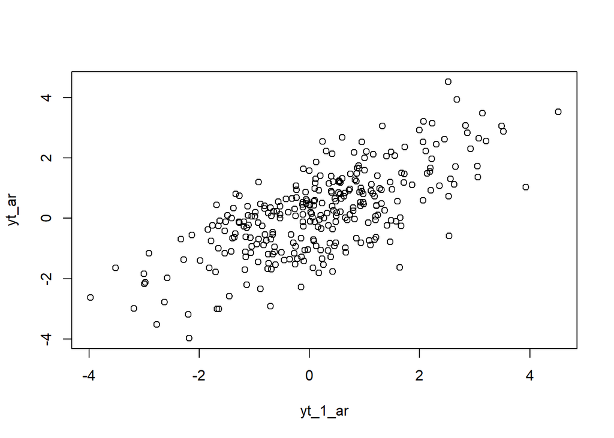

```r
plot(y=yt_ar,x=yt_1_ar)
```

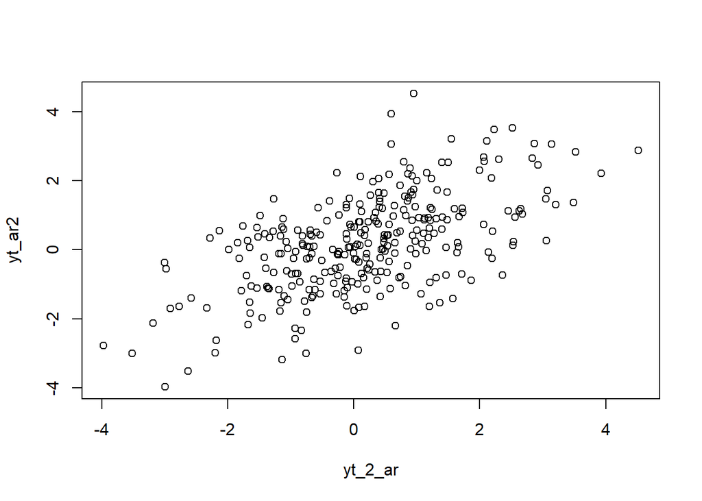

```r
plot(y=yt_ar2,x=yt_2_ar)
```

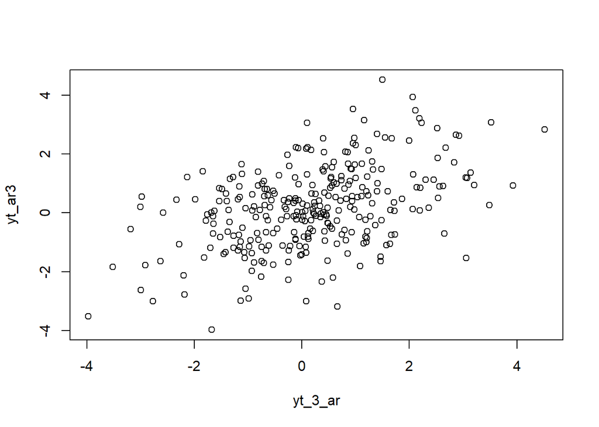

```r
plot(y=yt_ar3,x=yt_3_ar)
```

Berdasarkan scatterplot tersebut, terlihat bahwa ketiga plot menunjukkan terdapat hubungan positif yaitu antara $Y_t$ dengan $Y_{t-1}$, $Y_t$ dengan $Y_{t-2}$, dan $Y_t$ dengan $Y_{t-3}$. Hal ini sesuai dengan teori yang ada

```r
cor(yt_ar,yt_1_ar)
```

```
## [1] 0.7048041
```

```r
cor(yt_ar2,yt_2_ar)
```

```
## [1] 0.582014
```

```r
cor(yt_ar3,yt_3_ar)
```

```
## [1] 0.4523611
```

## Fungsi pembangkitan ARMA

Setelah mengetahui cara membangkitkan data berpola AR, MA, dan ARMA sederhana, bagaimana cara melakukan pembangkitan data berpola tersebut yang lebih kompleks? Apakah dapat dibuat suatu fungsi yang fleksibel yang memungkinan pembangkitan dengan berapapun jumlah koefisien?

Pertama, lihat kembali bentuk umum data berpola ARMA.

$$y_{t} = c + \sum_{i=1}^p \phi_{i}y_{t-i} + \sum_{j=1}^q e_{t-j}+ e_{t}$$

Komponen $c$ dan $e_{t}$ cukup mudah untuk dibuat dan dicari. Bagaimana untuk komponen AR dan MA? Bayangkan ada koefisien dan data sebagai berikut:

$$\begin{aligned}
\begin{bmatrix}
\phi_1 \ \phi_2 \ \phi_3
\end{bmatrix}&=
\begin{bmatrix}
0.3 \ 0.5 \ 0.2
\end{bmatrix}
\\
\begin{bmatrix}
y_{t-1} \ y_{t-2} \ y_{t-3}
\end{bmatrix}&=
\begin{bmatrix}
1 \ 2 \ 3
\end{bmatrix}
\end{aligned}$$

Maka dari itu,

$$\begin{aligned}
\begin{bmatrix}
\phi_1 \ \phi_2 \ \phi_3
\end{bmatrix}
\begin{bmatrix}
y_{t-1} \\ y_{t-2} \\ y_{t-3}
\end{bmatrix} &= \phi_1 \ y_{t-1}+\phi_2 \ y_{t-2}+\phi_3 \ y_{t-3}
\\
\begin{bmatrix}
0.3 \ 0.5 \ 0.2
\end{bmatrix}
\begin{bmatrix}
1 \\ 2 \\ 3
\end{bmatrix} & = 0.3 \cdot1+0.5 \cdot 2+0.2 \cdot 3\\
&=0.3+1+0.6 = 1.9
\end{aligned}$$

Jika koefisien dan *white noise*/nilai deret waktu sebelumnya dapat diekstrak dalam bentuk vektor, dapat dilakukan perkalian matriks untuk mencari nilai bagian AR dan MA:

```r
set.seed(1027)
coefs <- c(0.4, 0.6, 0.5, 0.2)
e <- c(1, 2, 3, 4)

coefs %*% e
```

```
##      [,1]
## [1,]  3.9
```

Atau, dapat dilakukan perkalian *elementwise* yang dijumlahkan:

```r
coefs * e
```

```
## [1] 0.4 1.2 1.5 0.8
```

```r
sum(coefs * e)
```

```
## [1] 3.9
```

Dari prinsip ini, dapat dibuat fungsi umum untuk membangkitkan data ARMA. Input dari fungsi adalah jumlah data yang hendak dibangkitkan, koefisien MA, dan koefisien AR

```r
arma.sim <- function(n, macoef, arcoef){
  manum <- length(macoef)
  arnum <- length(arcoef)
  stopifnot(manum < n & arnum < n)

  wn <- rnorm(n, sd = 0.5)
  init <- max(manum, arnum)

  arma <- wn[1:init]
  for(i in {init+1}:n){
   mastart <- i - manum
   maend <- i-1
   arstart <- i - arnum
   arend <- i-1
   arma[i] <- sum(arcoef * arma[arstart:arend]) + sum(macoef * wn[mastart:maend])  + wn[i]
   }
  return(arma)
}
```

Terlihat bahwa komponen $\sum_{i=1}^q y_{t-1}$ disimulasikan melalui `sum(arcoef * arma[arstart:arend])`. Jadi, koefisien dikalikan dengan data $y$ dari $t-q$ di mana q adalah jumlah koefisien AR, sampai data $t-1$. Lalu komponen $\sum_{j=1}^q e_{t-j}$ disimulasikan melalui `sum(macoef * wn[mastart:maend])`. Koefisien dikalikan dengan *white noise* $e$ dari $t-p$, p jumlah koefisien MA, sampai $t-1$.

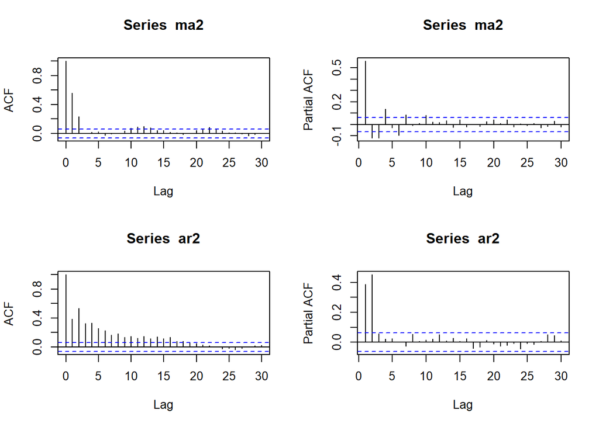

```r
# beberapa contoh pembangkitan melalui fungsi

ma2 <- arma.sim(1000, c(0.4, 0.6), 0)
ar2 <- arma.sim(1000, 0, c(0.5, 0.2))

par(mfrow = c(2, 2))
acf(ma2)
pacf(ma2)
acf(ar2)
pacf(ar2)
```

```r
#contoh untuk ARMA
arma22 <- arma.sim(3000, c(0.4, 0.6), c(0.5,0.2))

arma22 |> arima(c(2,0,2))
```

```
##
## Call:
## arima(x = arma22, order = c(2, 0, 2))
##
## Coefficients:
##          ar1     ar2     ma1     ma2  intercept
##       0.2166  0.4804  0.5967  0.3978     0.0084
## s.e.  0.0298  0.0290  0.0290  0.0203     0.0606
##
## sigma^2 estimated as 0.2553:  log likelihood = -2209.52,  aic = 4431.04
```

```r
set.seed(1027)
n = length(wn)
phi1 = 0.4
theta1 = 0.5

y.arma=c(1:n)
for (i in 3:n){y.arma[i] = phi1*y.arma[i-1] + theta1*wn[i-1]+wn[i]}
```

Pembangkitan ARMA(p,q) juga dapat dilakukan dengan fungsi `arima.sim` sebagai berikut.

```r
# Set the AR and MA coefficients
ar_coeffs <- c(0.5, 0.2)
ma_coeffs <- c(0.4, 0.6)

# Specify the order of the ARMA model
order <- c(2, 0, 2)

# Set the number of data points to generate
n <- 300

# Generate the ARMA(2,2) time series
arma22 <- arima.sim(model = list(order = order, ar = ar_coeffs, ma = ma_coeffs), n = n)
arma22
```

```
## Time Series:
## Start = 1
## End = 300
## Frequency = 1
##   [1] -3.44825403 -3.35711536 -1.26115574 -0.13095343  0.38877916  0.45808053
##   [7]  2.03926355  0.76415253  2.34202997  1.31219122  0.57012786 -0.78156648
##  [13] -2.04921983 -2.48021791 -1.71761574 -0.80243398 -1.57640907 -1.38923661
##  [19] -0.69986529 -0.54560624  1.03564516  0.99328947  2.21018865  2.97090376
##  [25]  1.62985038  0.78757337 -1.11462975 -2.54971208 -2.55761059 -2.95220281
##  [31] -2.02097536 -1.70816045 -1.26517933 -0.06295396 -0.41877965  0.21569579
##  [37] -0.71033890 -0.42936072 -1.07594680  0.57061519  1.63510518  1.84532453
##  [43]  1.01297345  0.70379852  1.12038720  0.40462771  0.72311823 -1.00327319
##  [49] -1.26863695 -1.57557209 -0.49469626 -0.11672387  0.34849172 -0.11560637
##  [55] -0.26047792  0.36833051  0.35911730  1.10928317 -0.21936352 -1.62892733
##  [61] -2.58338675 -3.03044323 -3.91635988 -2.55537015 -2.69845282 -1.38700792
```

[output cut: 39 more lines]

## Karakteristik ARMA(2,2)

### Plot Time Series

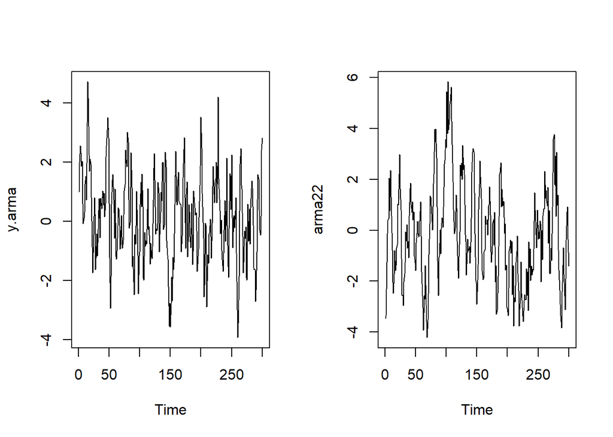

```r
par(mfrow = c(1, 2))
ts.plot(y.arma)
ts.plot(arma22)
```

```r
par(mfrow = c(1, 1))
```

### Plot ACF

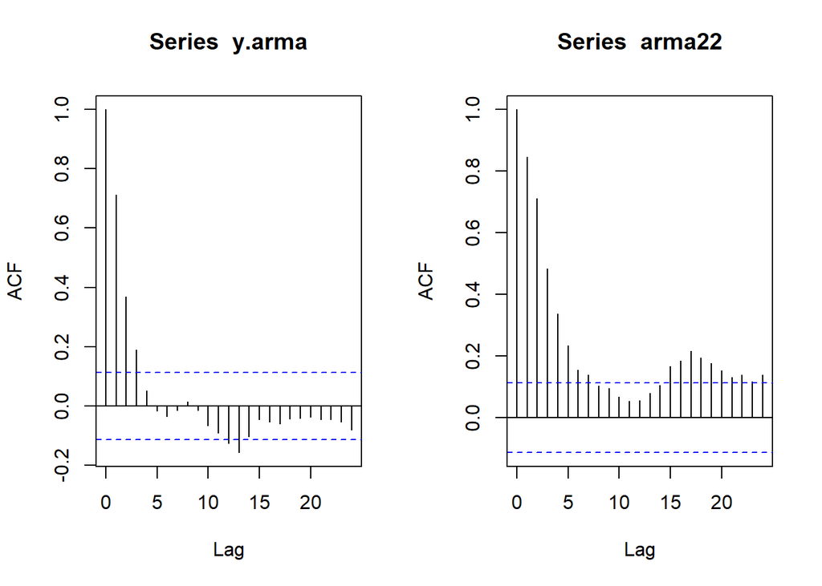

```r
par(mfrow = c(1, 2))
acf(y.arma)
acf(arma22)
```

```r
par(mfrow = c(1, 1))
```

Berdasarkan plot ACF tersebut, terlihat bahwa model ARMA(1,1) hasil simulasi memiliki plot ACF yang *tails off*, sesuai dengan teori yang ada

### Plot PACF

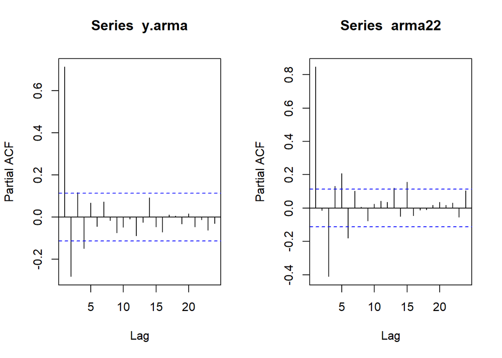

```r
par(mfrow = c(1, 2))
pacf(y.arma)
pacf(arma22)
```

```r
par(mfrow = c(1, 1))
```

Berdasarkan plot PACF tersebut, terlihat bahwa model ARMA(2,2) hasil simulasi memiliki plot PACF yang *tails off*, sesuai dengan teori

### Plot EACF

```r
TSA::eacf(y.arma)
```

```
## AR/MA
##   0 1 2 3 4 5 6 7 8 9 10 11 12 13
## 0 x x x o o o o o o o o  x  x  o
## 1 x o x o o o o o o o o  o  x  o
## 2 x o x o o o o o o o o  o  x  o
## 3 x x x o o o o o o o o  o  x  o
## 4 x o x o o o o o o o o  o  o  o
## 5 x o x o o o o o o o o  o  o  o
## 6 x x x o o x o o o o o  o  o  o
## 7 x x x o o x o o o o o  o  o  o
```

```r
TSA::eacf(arma22)
```

```
## AR/MA
##   0 1 2 3 4 5 6 7 8 9 10 11 12 13
## 0 x x x x x x x o o o o  o  o  o
## 1 o x o o o x o o o o o  o  o  o
## 2 o x o o o x o o o o o  o  o  o
## 3 x x o o o x o o o o o  o  o  o
## 4 x x o o o x x o o o o  o  o  o
## 5 x x o x x x o o o o o  o  o  o
## 6 x x o x o o o o o o x  o  o  o
## 7 x x o o o x o o o o x  o  o  o
```

### Scatterplot Antar Lag

#### Korelasi antara $Y_t$ dengan $Y_{t-1}$

```r
#Yt
yt_arma <- arma22[-1]
yt_arma
```

```
##   [1] -3.35711536 -1.26115574 -0.13095343  0.38877916  0.45808053  2.03926355
##   [7]  0.76415253  2.34202997  1.31219122  0.57012786 -0.78156648 -2.04921983
##  [13] -2.48021791 -1.71761574 -0.80243398 -1.57640907 -1.38923661 -0.69986529
##  [19] -0.54560624  1.03564516  0.99328947  2.21018865  2.97090376  1.62985038
##  [25]  0.78757337 -1.11462975 -2.54971208 -2.55761059 -2.95220281 -2.02097536
##  [31] -1.70816045 -1.26517933 -0.06295396 -0.41877965  0.21569579 -0.71033890
##  [37] -0.42936072 -1.07594680  0.57061519  1.63510518  1.84532453  1.01297345
##  [43]  0.70379852  1.12038720  0.40462771  0.72311823 -1.00327319 -1.26863695
##  [49] -1.57557209 -0.49469626 -0.11672387  0.34849172 -0.11560637 -0.26047792
##  [55]  0.36833051  0.35911730  1.10928317 -0.21936352 -1.62892733 -2.58338675
##  [61] -3.03044323 -3.91635988 -2.55537015 -2.69845282 -1.38700792 -2.92092726
##  [67] -3.60734900 -4.20928356 -3.51255849 -2.49889760 -0.95407086  0.25051206
##  [73]  1.34002963  1.28626725  0.65287083  0.34415343  0.01313711  1.83222907
##  [79]  2.20434955  3.95474918  3.48178670  3.97264763  2.84021364  0.91318625
##  [85] -1.21142563 -2.56503026 -1.08558281 -1.01780404  0.01581174 -0.91453273
```

[output cut: 35 more lines]

```r
#Yt-1
yt_1_arma <- arma22[-300]
yt_1_arma
```

```
##   [1] -3.44825403 -3.35711536 -1.26115574 -0.13095343  0.38877916  0.45808053
##   [7]  2.03926355  0.76415253  2.34202997  1.31219122  0.57012786 -0.78156648
##  [13] -2.04921983 -2.48021791 -1.71761574 -0.80243398 -1.57640907 -1.38923661
##  [19] -0.69986529 -0.54560624  1.03564516  0.99328947  2.21018865  2.97090376
##  [25]  1.62985038  0.78757337 -1.11462975 -2.54971208 -2.55761059 -2.95220281
##  [31] -2.02097536 -1.70816045 -1.26517933 -0.06295396 -0.41877965  0.21569579
##  [37] -0.71033890 -0.42936072 -1.07594680  0.57061519  1.63510518  1.84532453
##  [43]  1.01297345  0.70379852  1.12038720  0.40462771  0.72311823 -1.00327319
##  [49] -1.26863695 -1.57557209 -0.49469626 -0.11672387  0.34849172 -0.11560637
##  [55] -0.26047792  0.36833051  0.35911730  1.10928317 -0.21936352 -1.62892733
##  [61] -2.58338675 -3.03044323 -3.91635988 -2.55537015 -2.69845282 -1.38700792
##  [67] -2.92092726 -3.60734900 -4.20928356 -3.51255849 -2.49889760 -0.95407086
##  [73]  0.25051206  1.34002963  1.28626725  0.65287083  0.34415343  0.01313711
##  [79]  1.83222907  2.20434955  3.95474918  3.48178670  3.97264763  2.84021364
##  [85]  0.91318625 -1.21142563 -2.56503026 -1.08558281 -1.01780404  0.01581174
```

[output cut: 35 more lines]

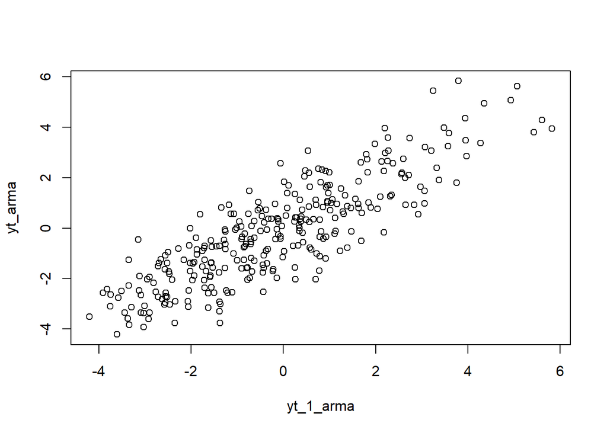

```r
plot(y=yt_arma,x=yt_1_arma)
```

```r
#Yt
yt_arma2 <- arma22[-c(1,3)]
yt_arma2
```

```
##   [1] -3.35711536 -0.13095343  0.38877916  0.45808053  2.03926355  0.76415253
##   [7]  2.34202997  1.31219122  0.57012786 -0.78156648 -2.04921983 -2.48021791
##  [13] -1.71761574 -0.80243398 -1.57640907 -1.38923661 -0.69986529 -0.54560624
##  [19]  1.03564516  0.99328947  2.21018865  2.97090376  1.62985038  0.78757337
##  [25] -1.11462975 -2.54971208 -2.55761059 -2.95220281 -2.02097536 -1.70816045
##  [31] -1.26517933 -0.06295396 -0.41877965  0.21569579 -0.71033890 -0.42936072
##  [37] -1.07594680  0.57061519  1.63510518  1.84532453  1.01297345  0.70379852
##  [43]  1.12038720  0.40462771  0.72311823 -1.00327319 -1.26863695 -1.57557209
##  [49] -0.49469626 -0.11672387  0.34849172 -0.11560637 -0.26047792  0.36833051
##  [55]  0.35911730  1.10928317 -0.21936352 -1.62892733 -2.58338675 -3.03044323
##  [61] -3.91635988 -2.55537015 -2.69845282 -1.38700792 -2.92092726 -3.60734900
##  [67] -4.20928356 -3.51255849 -2.49889760 -0.95407086  0.25051206  1.34002963
##  [73]  1.28626725  0.65287083  0.34415343  0.01313711  1.83222907  2.20434955
##  [79]  3.95474918  3.48178670  3.97264763  2.84021364  0.91318625 -1.21142563
##  [85] -2.56503026 -1.08558281 -1.01780404  0.01581174 -0.91453273  0.05386228
```

[output cut: 35 more lines]

```r
#Yt-2
yt_2_arma <- arma22[-c(299,300)]
yt_2_arma
```

```
##   [1] -3.44825403 -3.35711536 -1.26115574 -0.13095343  0.38877916  0.45808053
##   [7]  2.03926355  0.76415253  2.34202997  1.31219122  0.57012786 -0.78156648
##  [13] -2.04921983 -2.48021791 -1.71761574 -0.80243398 -1.57640907 -1.38923661
##  [19] -0.69986529 -0.54560624  1.03564516  0.99328947  2.21018865  2.97090376
##  [25]  1.62985038  0.78757337 -1.11462975 -2.54971208 -2.55761059 -2.95220281
##  [31] -2.02097536 -1.70816045 -1.26517933 -0.06295396 -0.41877965  0.21569579
##  [37] -0.71033890 -0.42936072 -1.07594680  0.57061519  1.63510518  1.84532453
##  [43]  1.01297345  0.70379852  1.12038720  0.40462771  0.72311823 -1.00327319
##  [49] -1.26863695 -1.57557209 -0.49469626 -0.11672387  0.34849172 -0.11560637
##  [55] -0.26047792  0.36833051  0.35911730  1.10928317 -0.21936352 -1.62892733
##  [61] -2.58338675 -3.03044323 -3.91635988 -2.55537015 -2.69845282 -1.38700792
##  [67] -2.92092726 -3.60734900 -4.20928356 -3.51255849 -2.49889760 -0.95407086
##  [73]  0.25051206  1.34002963  1.28626725  0.65287083  0.34415343  0.01313711
##  [79]  1.83222907  2.20434955  3.95474918  3.48178670  3.97264763  2.84021364
##  [85]  0.91318625 -1.21142563 -2.56503026 -1.08558281 -1.01780404  0.01581174
```

[output cut: 35 more lines]

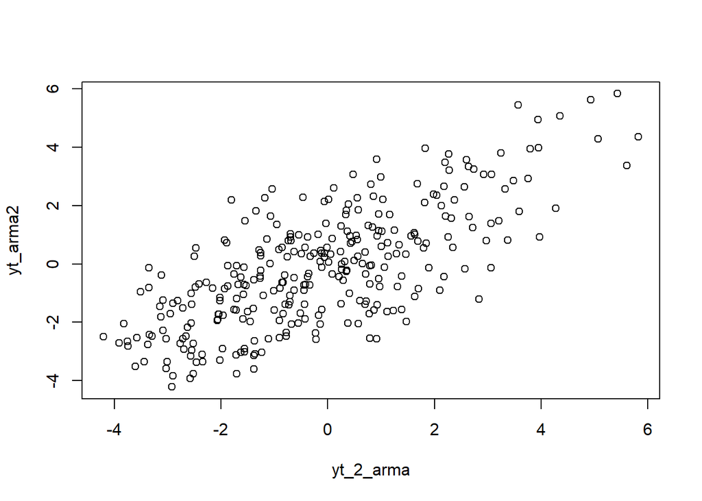

```r
plot(y=yt_arma2,x=yt_2_arma)
```

Berdasarkan scatterplot tersebut, terlihat bahwa terdapat hubungan positif antara $Y_t$ dengan $Y_{t-2}$. Hal ini sesuai dengan teori yang ada

```r
#Yt
yt_arma3 <- arma22[-c(1,2,3)]
yt_arma3
```

```
##   [1] -0.13095343  0.38877916  0.45808053  2.03926355  0.76415253  2.34202997
##   [7]  1.31219122  0.57012786 -0.78156648 -2.04921983 -2.48021791 -1.71761574
##  [13] -0.80243398 -1.57640907 -1.38923661 -0.69986529 -0.54560624  1.03564516
##  [19]  0.99328947  2.21018865  2.97090376  1.62985038  0.78757337 -1.11462975
##  [25] -2.54971208 -2.55761059 -2.95220281 -2.02097536 -1.70816045 -1.26517933
##  [31] -0.06295396 -0.41877965  0.21569579 -0.71033890 -0.42936072 -1.07594680
##  [37]  0.57061519  1.63510518  1.84532453  1.01297345  0.70379852  1.12038720
##  [43]  0.40462771  0.72311823 -1.00327319 -1.26863695 -1.57557209 -0.49469626
##  [49] -0.11672387  0.34849172 -0.11560637 -0.26047792  0.36833051  0.35911730
##  [55]  1.10928317 -0.21936352 -1.62892733 -2.58338675 -3.03044323 -3.91635988
##  [61] -2.55537015 -2.69845282 -1.38700792 -2.92092726 -3.60734900 -4.20928356
##  [67] -3.51255849 -2.49889760 -0.95407086  0.25051206  1.34002963  1.28626725
##  [73]  0.65287083  0.34415343  0.01313711  1.83222907  2.20434955  3.95474918
##  [79]  3.48178670  3.97264763  2.84021364  0.91318625 -1.21142563 -2.56503026
##  [85] -1.08558281 -1.01780404  0.01581174 -0.91453273  0.05386228  0.49815998
```

[output cut: 35 more lines]

```r
#Yt-3
yt_3_arma <- arma22[-c(298,299,300)]
yt_3_arma
```

```
##   [1] -3.44825403 -3.35711536 -1.26115574 -0.13095343  0.38877916  0.45808053
##   [7]  2.03926355  0.76415253  2.34202997  1.31219122  0.57012786 -0.78156648
##  [13] -2.04921983 -2.48021791 -1.71761574 -0.80243398 -1.57640907 -1.38923661
##  [19] -0.69986529 -0.54560624  1.03564516  0.99328947  2.21018865  2.97090376
##  [25]  1.62985038  0.78757337 -1.11462975 -2.54971208 -2.55761059 -2.95220281
##  [31] -2.02097536 -1.70816045 -1.26517933 -0.06295396 -0.41877965  0.21569579
##  [37] -0.71033890 -0.42936072 -1.07594680  0.57061519  1.63510518  1.84532453
##  [43]  1.01297345  0.70379852  1.12038720  0.40462771  0.72311823 -1.00327319
##  [49] -1.26863695 -1.57557209 -0.49469626 -0.11672387  0.34849172 -0.11560637
##  [55] -0.26047792  0.36833051  0.35911730  1.10928317 -0.21936352 -1.62892733
##  [61] -2.58338675 -3.03044323 -3.91635988 -2.55537015 -2.69845282 -1.38700792
##  [67] -2.92092726 -3.60734900 -4.20928356 -3.51255849 -2.49889760 -0.95407086
##  [73]  0.25051206  1.34002963  1.28626725  0.65287083  0.34415343  0.01313711
##  [79]  1.83222907  2.20434955  3.95474918  3.48178670  3.97264763  2.84021364
##  [85]  0.91318625 -1.21142563 -2.56503026 -1.08558281 -1.01780404  0.01581174
```

[output cut: 35 more lines]

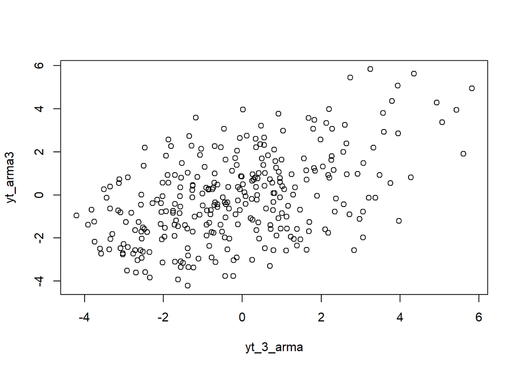

```r
plot(y=yt_arma3,x=yt_3_arma)
```

```r
cor(yt_arma,yt_1_arma)
```

```
## [1] 0.8507115
```

```r
cor(yt_arma2,yt_2_arma)
```

```
## [1] 0.7219091
```

```r
cor(yt_arma3,yt_3_arma)
```

```
## [1] 0.4878708
```